# CT-project-documented

## Labeling and Train-Test Split

With the stored paths, images are loaded iteratively using the "process_scan" function. The loaded scans are converted and stored in 3D arrays. Labels are made for abnormal and normal scans. The data is split into train, validation sets

```python
# Read and process the scans.
# Each scan is resized across height, width, and depth and rescaled.
abnormal_scans = np.array([process_scan(path) for path in abnormal_scan_paths])
normal_scans = np.array([process_scan(path) for path in normal_scan_paths])

# For the CT scans having presence of viral pneumonia
# assign 1, for the normal ones assign 0.
abnormal_labels = np.array([1 for _ in range(len(abnormal_scans))])
normal_labels = np.array([0 for _ in range(len(normal_scans))])

# Split data in the ratio 70-30 for training and validation.
x_train = np.concatenate((abnormal_scans[:70], normal_scans[:70]), axis=0)
y_train = np.concatenate((abnormal_labels[:70], normal_labels[:70]), axis=0)
x_val = np.concatenate((abnormal_scans[70:], normal_scans[70:]), axis=0)
y_val = np.concatenate((abnormal_labels[70:], normal_labels[70:]), axis=0)
print(
    "Number of samples in train and validation are %d and %d."
    % (x_train.shape[0], x_val.shape[0])
)
```

```
Number of samples in train and validation are 140 and 60.
```

### Rotating Train set

Functions for preprocessing the training and validation data for CNN are below. The training data is rotated and an additional channel added. The validation data has an additional channel added

```python
@tf.function
def rotate(volume):
    """Rotate the volume by a few degrees"""

    def scipy_rotate(volume):
        # define some rotation angles
        angles = [-20, -10, -5, 5, 10, 20]
        # pick angles at random
        angle = random.choice(angles)
        # rotate volume
        volume = ndimage.rotate(volume, angle, reshape=False)
        volume[volume < 0] = 0
        volume[volume > 1] = 1
        return volume

    augmented_volume = tf.numpy_function(scipy_rotate, [volume], tf.float32)
    return augmented_volume


def train_preprocessing(volume, label):
    """Process training data by rotating and adding a channel."""
    # Rotate volume
    volume = rotate(volume)
    volume = tf.expand_dims(volume, axis=3)
    return volume, label


def validation_preprocessing(volume, label):
    """Process validation data by only adding a channel."""
    volume = tf.expand_dims(volume, axis=3)
    return volume, label
```

Tensorflow pipelines are made below. This makes it easier to train the CNN without running out of resources (eg memory)

```python
# Create tensorflow input pipelines
train_input_pipeline = tf.data.Dataset.from_tensor_slices((x_train, y_train))
validation_input_pipeline = tf.data.Dataset.from_tensor_slices((x_val, y_val))

batch_size = 2

# transform and rotate the data using the map function
train_dataset = train_input_pipeline.shuffle(len(x_train)).map(train_preprocessing).batch(batch_size).prefetch(2)

# transform the data using the map function
validation_dataset = validation_input_pipeline.shuffle(len(x_val)).map(validation_preprocessing).batch(batch_size).prefetch(2)
```

```python
# Showing shape of inputs into the CNN
data = train_dataset.take(10)
type(train_dataset)
images, label = list(data)[0]
print(type(images))
print(type(label))
images_np = images.numpy()
label_np = label.numpy()
print(images_np.shape)
print(label_np.shape)
label_np_1 = label_np[0]
images_np_1 = images_np[0]
print(images_np_1.shape)
```

```
<class 'tensorflow.python.framework.ops.EagerTensor'>
<class 'tensorflow.python.framework.ops.EagerTensor'>
(2, 128, 128, 64, 1)
(2,)
(128, 128, 64, 1)
```

```
Dimension of the CT scan is: (128, 128, 64, 1)
```

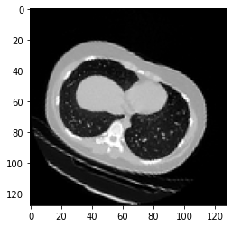

```python
import matplotlib.pyplot as plt

data = train_dataset.take(1)
images, labels = list(data)[0]
images = images.numpy()
image = images[0]
print("Dimension of the CT scan is:", image.shape)
plt.imshow(np.squeeze(image[:, :, 30]), cmap="gray")
```

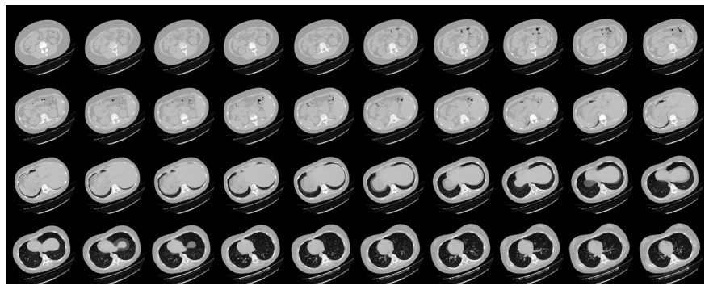

```python
def plot_slices(num_rows, num_columns, width, height, data):
    """Plot a montage of 20 CT slices"""
    data = np.rot90(np.array(data))
    data = np.transpose(data)
    data = np.reshape(data, (num_rows, num_columns, width, height))
    rows_data, columns_data = data.shape[0], data.shape[1]
    heights = [slc[0].shape[0] for slc in data]
    widths = [slc.shape[1] for slc in data[0]]
    fig_width = 12.0
    fig_height = fig_width * sum(heights) / sum(widths)
    f, axarr = plt.subplots(
        rows_data,
        columns_data,
        figsize=(fig_width, fig_height),
        gridspec_kw={"height_ratios": heights},
    )
    for i in range(rows_data):
        for j in range(columns_data):
            axarr[i, j].imshow(data[i][j], cmap="gray")
            axarr[i, j].axis("off")
    plt.subplots_adjust(wspace=0, hspace=0, left=0, right=1, bottom=0, top=1)
    plt.show()


# Visualize montage of slices.
# 4 rows and 10 columns for 100 slices of the CT scan.
plot_slices(4, 10, 128, 128, image[:, :, :40])
```

## Build and compile CNN model

```python
def get_model(width=128, height=128, depth=64):
    """Build a 3D convolutional neural network model."""

    inputs = keras.Input((width, height, depth, 1))

    x = layers.Conv3D(filters=64, kernel_size=3, activation="relu")(inputs)
    x = layers.MaxPool3D(pool_size=2)(x)
    x = layers.BatchNormalization()(x)

    x = layers.Conv3D(filters=64, kernel_size=3, activation="relu")(x)
    x = layers.MaxPool3D(pool_size=2)(x)
    x = layers.BatchNormalization()(x)

    x = layers.Conv3D(filters=128, kernel_size=3, activation="relu")(x)
    x = layers.MaxPool3D(pool_size=2)(x)
    x = layers.BatchNormalization()(x)

    x = layers.Conv3D(filters=256, kernel_size=3, activation="relu")(x)
    x = layers.MaxPool3D(pool_size=2)(x)
    x = layers.BatchNormalization()(x)

    x = layers.GlobalAveragePooling3D()(x)
    x = layers.Dense(units=512, activation="relu")(x)
    x = layers.Dropout(0.3)(x)

    outputs = layers.Dense(units=1, activation="sigmoid")(x)

    # Define the model.
    model = keras.Model(inputs, outputs, name="3dcnn")
    return model


# Build model.
model = get_model(width=128, height=128, depth=64)
model.summary()
```

```
Model: "3dcnn"
_________________________________________________________________
Layer (type)                 Output Shape              Param #
=================================================================
input_1 (InputLayer)         [(None, 128, 128, 64, 1)] 0
_________________________________________________________________
conv3d (Conv3D)              (None, 126, 126, 62, 64)  1792
_________________________________________________________________
max_pooling3d (MaxPooling3D) (None, 63, 63, 31, 64)    0
_________________________________________________________________
batch_normalization (BatchNo (None, 63, 63, 31, 64)    256
_________________________________________________________________
conv3d_1 (Conv3D)            (None, 61, 61, 29, 64)    110656
_________________________________________________________________
max_pooling3d_1 (MaxPooling3 (None, 30, 30, 14, 64)    0
_________________________________________________________________
batch_normalization_1 (Batch (None, 30, 30, 14, 64)    256
_________________________________________________________________
conv3d_2 (Conv3D)            (None, 28, 28, 12, 128)   221312
_________________________________________________________________
max_pooling3d_2 (MaxPooling3 (None, 14, 14, 6, 128)    0
_________________________________________________________________
batch_normalization_2 (Batch (None, 14, 14, 6, 128)    512
_________________________________________________________________
conv3d_3 (Conv3D)            (None, 12, 12, 4, 256)    884992
_________________________________________________________________
max_pooling3d_3 (MaxPooling3 (None, 6, 6, 2, 256)      0
_________________________________________________________________
batch_normalization_3 (Batch (None, 6, 6, 2, 256)      1024
_________________________________________________________________
global_average_pooling3d (Gl (None, 256)               0
_________________________________________________________________
dense (Dense)                (None, 512)               131584
_________________________________________________________________
dropout (Dropout)            (None, 512)               0
_________________________________________________________________
dense_1 (Dense)              (None, 1)                 513
=================================================================
Total params: 1,352,897
Trainable params: 1,351,873
Non-trainable params: 1,024
_________________________________________________________________
```

```python
# Compile model.
initial_learning_rate = 0.0001
lr_schedule = keras.optimizers.schedules.ExponentialDecay(
    initial_learning_rate, decay_steps=100000, decay_rate=0.96, staircase=True
)
model.compile(
    loss="binary_crossentropy",
    optimizer=keras.optimizers.Adam(learning_rate=lr_schedule),
    metrics=["acc"],
)

# Define callbacks.
checkpoint_cb = keras.callbacks.ModelCheckpoint(
    "3d_image_classification.h5", save_best_only=True, verbose=True
)
early_stopping_cb = keras.callbacks.EarlyStopping(monitor="val_acc", patience=15, verbose=True)

# Train the model, doing validation at the end of each epoch
epochs = 100
model.fit(
    train_dataset,
    validation_data=validation_dataset,
    epochs=epochs,
    shuffle=True,
    verbose=2,
    callbacks=[checkpoint_cb, early_stopping_cb],
)
```

```
WARNING:tensorflow:Callbacks method `on_train_batch_end` is slow compared to the batch time (batch time: 0.0292s vs `on_train_batch_end` time: 0.0802s). Check your callbacks.
WARNING:tensorflow:Callbacks method `on_train_batch_end` is slow compared to the batch time (batch time: 0.0292s vs `on_train_batch_end` time: 0.0802s). Check your callbacks.

Epoch 00001: val_loss improved from inf to 0.71942, saving model to 3d_image_classification.h5
70/70 - 28s - loss: 0.7138 - acc: 0.5286 - val_loss: 0.7194 - val_acc: 0.5000

Epoch 00002: val_loss did not improve from 0.71942
70/70 - 28s - loss: 0.6587 - acc: 0.6000 - val_loss: 1.3255 - val_acc: 0.5000

Epoch 00003: val_loss did not improve from 0.71942
70/70 - 28s - loss: 0.6800 - acc: 0.5714 - val_loss: 1.1438 - val_acc: 0.5000

Epoch 00004: val_loss did not improve from 0.71942
70/70 - 28s - loss: 0.6322 - acc: 0.6143 - val_loss: 1.0400 - val_acc: 0.5000

Epoch 00005: val_loss did not improve from 0.71942
70/70 - 28s - loss: 0.6047 - acc: 0.6429 - val_loss: 2.3341 - val_acc: 0.5000

Epoch 00006: val_loss did not improve from 0.71942
70/70 - 28s - loss: 0.6224 - acc: 0.6500 - val_loss: 1.6982 - val_acc: 0.5000

Epoch 00007: val_loss did not improve from 0.71942
70/70 - 28s - loss: 0.6185 - acc: 0.6857 - val_loss: 1.3129 - val_acc: 0.5000

Epoch 00008: val_loss did not improve from 0.71942
70/70 - 28s - loss: 0.6080 - acc: 0.6571 - val_loss: 1.5393 - val_acc: 0.5000

Epoch 00009: val_loss did not improve from 0.71942
70/70 - 28s - loss: 0.5853 - acc: 0.7071 - val_loss: 1.3470 - val_acc: 0.5000

Epoch 00010: val_loss did not improve from 0.71942
70/70 - 28s - loss: 0.5809 - acc: 0.6786 - val_loss: 0.7470 - val_acc: 0.5833

Epoch 00011: val_loss improved from 0.71942 to 0.66128, saving model to 3d_image_classification.h5
70/70 - 29s - loss: 0.5885 - acc: 0.7000 - val_loss: 0.6613 - val_acc: 0.6000

Epoch 00012: val_loss did not improve from 0.66128
70/70 - 29s - loss: 0.5900 - acc: 0.6786 - val_loss: 0.8998 - val_acc: 0.6333

Epoch 00013: val_loss did not improve from 0.66128
```

[output cut: 44 more lines]

```
Epoch 00028: val_loss did not improve from 0.57524
70/70 - 28s - loss: 0.4472 - acc: 0.8071 - val_loss: 0.6473 - val_acc: 0.7333

Epoch 00029: val_loss did not improve from 0.57524
70/70 - 28s - loss: 0.4041 - acc: 0.8357 - val_loss: 0.8238 - val_acc: 0.6167

Epoch 00030: val_loss did not improve from 0.57524
70/70 - 28s - loss: 0.3709 - acc: 0.8571 - val_loss: 0.5922 - val_acc: 0.7333

Epoch 00031: val_loss did not improve from 0.57524
70/70 - 28s - loss: 0.4466 - acc: 0.7786 - val_loss: 1.0057 - val_acc: 0.5667

Epoch 00032: val_loss improved from 0.57524 to 0.56161, saving model to 3d_image_classification.h5
70/70 - 29s - loss: 0.3908 - acc: 0.8214 - val_loss: 0.5616 - val_acc: 0.7333
Epoch 00032: early stopping
```

```
<tensorflow.python.keras.callbacks.History at 0x7f7b680d0208>
```

## Visualizing model performance

Here the model accuracy and loss for the training and the validation sets are plotted. Since the validation set is class-balanced, accuracy provides an unbiased representation of the model's performance.

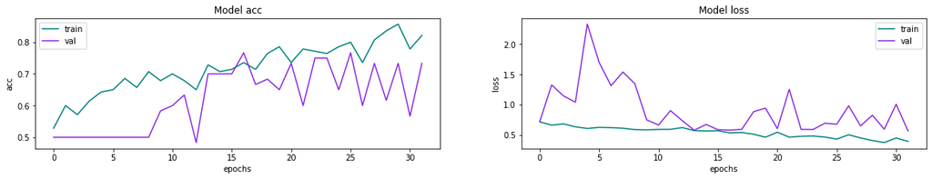

```python
fig, ax = plt.subplots(1, 2, figsize=(20, 3))
ax = ax.ravel()

for i, metric in enumerate(["acc", "loss"]):
    ax[i].plot(model.history.history[metric])
    ax[i].plot(model.history.history["val_" + metric])
    ax[i].set_title("Model {}".format(metric))
    ax[i].set_xlabel("epochs")
    ax[i].set_ylabel(metric)
    ax[i].legend(["train", "val"])
```

## Make predictions on a single CT scan

```python
# Load best weights.
model.load_weights("3d_image_classification.h5")
prediction = model.predict(np.expand_dims(x_val[0], axis=0))[0]

print("This model is %.2f percent confident that CT scan is abnormal" % (100 * prediction))
```

```
This model is 0.17 percent confident that CT scan is abnormal
```

```python
# Load best weights.
model.load_weights("3d_image_classification.h5")

predictions = [0]*len(y_val)
num = 0
for index in range(len(x_val)):
    predicted_percent = model.predict(np.expand_dims(x_val[index], axis=0))[0]
    if predicted_percent >= 0.5:
        predictions[index] = 1
    else:
        predictions[index] = 0

    if predictions[index] == y_val[index]:
        num += 1

accuracy = num/len(y_val)


print("The model is %.2f percent accurate on validation data" % (100 * accuracy))
```

```
The model is 73.33 percent accurate on validation data
```

## Create Model Artifact

```python
from ads.common.model_export_util import prepare_generic_model
```

```python
#Create directory to store your model artifact
os.makedirs("model_artifact")
```

```python
#use ADS to create the artifact
model_path = "/home/datascience/model_artifact"
```

```python
model_artifact = prepare_generic_model(model_path, force_overwrite=True, data_science_env=True)
```

[output not shown]

```python
conv_model = tf.keras.models.load_model("3d_image_classification.h5")
predictions = conv_model.predict(np.expand_dims(x_val[0], axis=0))[0]
print("This model is %.2f percent confident that CT scan is abnormal" % (100 * predictions))
```

```
WARNING:tensorflow:6 out of the last 66 calls to <function Model.make_predict_function.<locals>.predict_function at 0x7f7bb50171e0> triggered tf.function retracing. Tracing is expensive and the excessive number of tracings could be due to (1) creating @tf.function repeatedly in a loop, (2) passing t…
WARNING:tensorflow:6 out of the last 66 calls to <function Model.make_predict_function.<locals>.predict_function at 0x7f7bb50171e0> triggered tf.function retracing. Tracing is expensive and the excessive number of tracings could be due to (1) creating @tf.function repeatedly in a loop, (2) passing t…
This model is 0.17 percent confident that CT scan is abnormal
```

```python
#changes made in the scor.py file, check it out then reloaded
model_artifact.reload()
```

```python
a=model_artifact.model.predict(np.expand_dims(x_val[2], axis=0))
```

[output not shown]

```python
a[0][0]
```

```
0.84771705
```

## Saving Model in the Model Catalog

```python
compartment_id = os.environ['NB_SESSION_COMPARTMENT_OCID']
project_id = os.environ["PROJECT_OCID"]
```

```python
# Saving the model artifact to the model catalog:
mc_model = model_artifact.save(project_id=project_id, compartment_id=compartment_id, display_name="3D CNN on CT data",
description="3D image classification from CT scans", training_script_path="CT-project.ipynb", ignore_pending_changes=True)
```

```
INFO:ADS:{
  "git_branch": "None",
  "git_commit": "None",
  "repository_url": "None",
  "script_dir": "/home/datascience/model_artifact",
  "training_script": "/home/datascience/CT-project.ipynb"
}
```